# Heart Stroke Prediction - Code & Technical Analysis, Part - 2

Team KAT

2023-05-01

# 1 Introduction

Cardiovascular diseases (CVDs) are the number 1 cause of death globally, taking an estimated 17.9 million lives each year, which accounts for 31% of all deaths worldwide.

Most cardiovascular diseases can be prevented by addressing behavioral risk factors such as tobacco use, unhealthy diet and obesity, physical inactivity using population-wide strategies.

Reference: https://www.who.int/en/news-room/fact-sheets/detail/cardiovascular-diseases-(cvds)

## 1.1 Source of the dataset

This heart stroke dataset is from kaggle platform. The variables are:

| Variable | Definition |
| --- | --- |
| male | Patient sex (Gender) |
| age | Patient age (Numerical) |
| education | Patient education level (Numerical) |
| currentSmoker | No - 0, Yes - 1 |
| cigsPerDay | Number of cigarettes consumed by the person (Numerical) |
| BPMeds | If under Medication for BP |
| prevalentStroke | Patient history of heart stroke |
| prevalentHyper | Patient history of hypertension |
| diabetes | Patient history of diabetes |
| totChol | Patient cholestrol level (Numerical) |
| sysBP | Patient systolic blood pressure level (Numerical) |
| diaBP | Patient systolic blood pressure level (Numerical) |
| BMI | Patient body mass index value (Numerical) |
| heartRate | Patient heart rate value (Numerical) |
| glucose | Patient glucose level (Numerical) |
| stroke (Target variable) | Patient stroke chance (Ten year risk of coronary heart disease) |

Source link: https://www.kaggle.com/datasets/dileep070/heart-disease-prediction-using-logistic-regression

```r
github_file_path <-
  "https://raw.githubusercontent.com/kashyapnimmagadda/DATS-6101-GROUP-KAT/main/DataSet/framingham.csv"
stroke_df <- read.csv(url(github_file_path))
```

## 1.2 Sample record elements of stroke dataframe

```r
head(stroke_df, n = 5)
```

```
##   male age education currentSmoker cigsPerDay BPMeds prevalentStroke
## 1    1  39         4             0          0      0               0
## 2    0  46         2             0          0      0               0
## 3    1  48         1             1         20      0               0
## 4    0  61         3             1         30      0               0
## 5    0  46         3             1         23      0               0
##   prevalentHyp diabetes totChol sysBP diaBP   BMI heartRate glucose TenYearCHD
## 1            0        0     195 106.0    70 26.97        80      77          0
## 2            0        0     250 121.0    81 28.73        95      76          0
## 3            0        0     245 127.5    80 25.34        75      70          0
## 4            1        0     225 150.0    95 28.58        65     103          1
## 5            0        0     285 130.0    84 23.10        85      85          0
```

# 2 Summary of the dataset

```r
names(stroke_df)[names(stroke_df) == "TenYearCHD"] <- "stroke"
colnames(stroke_df)[1] <- "gender"

stroke_df$gender[stroke_df$gender == "0"] <- "F"
stroke_df$gender[stroke_df$gender == "1"] <- "M"

# converting the numeric variables to factor variables
stroke_df$gender <- as.factor(stroke_df$gender)
stroke_df$currentSmoker <- as.factor(stroke_df$currentSmoker)
stroke_df$BPMeds <- as.factor(stroke_df$BPMeds)
stroke_df$prevalentStroke <- as.factor(stroke_df$prevalentStroke)
stroke_df$prevalentHyp <- as.factor(stroke_df$prevalentHyp)
stroke_df$diabetes <- as.factor(stroke_df$diabetes)
stroke_df$stroke <- as.factor(stroke_df$stroke)
stroke_df$BMI <- as.numeric(stroke_df$BMI)

# To get the summary statistics of the dataset
summary(stroke_df)
```

```
##  gender        age          education     currentSmoker   cigsPerDay
##  F:2419   Min.   :32.00   Min.   :1.000   0:2144        Min.   : 0.000
##  M:1819   1st Qu.:42.00   1st Qu.:1.000   1:2094        1st Qu.: 0.000
##           Median :49.00   Median :2.000                 Median : 0.000
##           Mean   :49.58   Mean   :1.979                 Mean   : 9.003
##           3rd Qu.:56.00   3rd Qu.:3.000                 3rd Qu.:20.000
##           Max.   :70.00   Max.   :4.000                 Max.   :70.000
##                           NA's   :105                   NA's   :29
##   BPMeds     prevalentStroke prevalentHyp diabetes    totChol
##  0   :4061   0:4213          0:2922       0:4129   Min.   :107.0
##  1   : 124   1:  25          1:1316       1: 109   1st Qu.:206.0
##  NA's:  53                                         Median :234.0
##                                                    Mean   :236.7
##                                                    3rd Qu.:263.0
##                                                    Max.   :696.0
##                                                    NA's   :50
##      sysBP           diaBP             BMI          heartRate
##  Min.   : 83.5   Min.   : 48.00   Min.   :15.54   Min.   : 44.00
##  1st Qu.:117.0   1st Qu.: 75.00   1st Qu.:23.07   1st Qu.: 68.00
##  Median :128.0   Median : 82.00   Median :25.40   Median : 75.00
##  Mean   :132.4   Mean   : 82.89   Mean   :25.80   Mean   : 75.88
##  3rd Qu.:144.0   3rd Qu.: 89.88   3rd Qu.:28.04   3rd Qu.: 83.00
##  Max.   :295.0   Max.   :142.50   Max.   :56.80   Max.   :143.00
##                                   NA's   :19      NA's   :1
##     glucose       stroke
##  Min.   : 40.00   0:3594
##  1st Qu.: 71.00   1: 644
##  Median : 78.00
##  Mean   : 81.97
##  3rd Qu.: 87.00
##  Max.   :394.00
##  NA's   :388
```

# 3 Data Cleaning - Checking for null values

```r
paste("The NA's in the dataset is:", sum(is.na(stroke_df)))
```

```
## [1] "The NA's in the dataset is: 645"
```

```r
# Replacing cigsPerDay NA values with mean value
stroke_df$cigsPerDay[is.na(stroke_df$cigsPerDay)] <-
  mean(stroke_df$cigsPerDay, na.rm = TRUE)

# Replacing Education NA values with mean value
stroke_df$education[is.na(stroke_df$education)] <-
  mean(stroke_df$education, na.rm = TRUE)
stroke_df$education <- as.integer(stroke_df$education)

# Replacing BPMeds NA values with mean value
# stroke_df$BPMeds[is.na(stroke_df$BPMeds)] = mean(stroke_df$BPMeds, na.rm = TRUE)
# stroke_df$BPMeds <- as.integer(stroke_df$BPMeds)
stroke_df$BPMeds[is.na(stroke_df$BPMeds)] <- 0



# Replacing HeartRate NA values with mean value
stroke_df$heartRate[is.na(stroke_df$heartRate)] <-
  mean(stroke_df$heartRate, na.rm = TRUE)


# Replacing NA values with average BMI value
stroke_df$BMI[is.na(stroke_df$BMI)] <-
  mean(stroke_df$BMI, na.rm = TRUE)


# Replacing NA values with average glucose value
stroke_df$glucose[is.na(stroke_df$glucose)] <-
  mean(stroke_df$glucose, na.rm = TRUE)


# Replacing NA values with average totChol value
stroke_df$totChol[is.na(stroke_df$totChol)] <-
  mean(stroke_df$totChol, na.rm = TRUE)


paste("The NA's in the dataset after replacing null values is:", sum(is.na(stroke_df)))
```

```
## [1] "The NA's in the dataset after replacing null values is: 0"
```

## 3.1 Summary after data-cleaning

```r
# To get the summary statistics of the dataset

xkablesummary(stroke_df,
  title = "Table : Statistical Summary after cleaning",
  pos = "center",
  bso = "hover"
)
```

Table : Statistical Summary after cleaning

|  | gender | age | education | currentSmoker | cigsPerDay | BPMeds | prevalentStroke | prevalentHyp | diabetes | totChol | sysBP | diaBP | BMI | heartRate | glucose | stroke |
| --- | --- | --- | --- | --- | --- | --- | --- | --- | --- | --- | --- | --- | --- | --- | --- | --- |
| Min | F:2419 | Min. :32.00 | Min. :1.000 | 0:2144 | Min. : 0.000 | 0:4114 | 0:4213 | 0:2922 | 0:4129 | Min. :107.0 | Min. : 83.5 | Min. : 48.00 | Min. :15.54 | Min. : 44.00 | Min. : 40.00 | 0:3594 |
| Q1 | M:1819 | 1st Qu.:42.00 | 1st Qu.:1.000 | 1:2094 | 1st Qu.: 0.000 | 1: 124 | 1: 25 | 1:1316 | 1: 109 | 1st Qu.:206.0 | 1st Qu.:117.0 | 1st Qu.: 75.00 | 1st Qu.:23.08 | 1st Qu.: 68.00 | 1st Qu.: 72.00 | 1: 644 |
| Median | NA | Median :49.00 | Median :2.000 | NA | Median : 0.000 | NA | NA | NA | NA | Median :234.0 | Median :128.0 | Median : 82.00 | Median :25.41 | Median : 75.00 | Median : 80.00 | NA |
| Mean | NA | Mean :49.58 | Mean :1.955 | NA | Mean : 9.003 | NA | NA | NA | NA | Mean :236.7 | Mean :132.4 | Mean : 82.89 | Mean :25.80 | Mean : 75.88 | Mean : 81.97 | NA |
| Q3 | NA | 3rd Qu.:56.00 | 3rd Qu.:3.000 | NA | 3rd Qu.:20.000 | NA | NA | NA | NA | 3rd Qu.:262.0 | 3rd Qu.:144.0 | 3rd Qu.: 89.88 | 3rd Qu.:28.04 | 3rd Qu.: 83.00 | 3rd Qu.: 85.00 | NA |
| Max | NA | Max. :70.00 | Max. :4.000 | NA | Max. :70.000 | NA | NA | NA | NA | Max. :696.0 | Max. :295.0 | Max. :142.50 | Max. :56.80 | Max. :143.00 | Max. :394.00 | NA |

```r
# subsetting the data for various analyses
stroke_1 <- subset(stroke_df, stroke == 1)
stroke_0 <- subset(stroke_df, stroke == 0)
stroke_1_female <- subset(stroke_df, stroke == 1 & gender == "F")
stroke_1_male <- subset(stroke_df, stroke == 1 & gender == "M")

# creating different columns for bmi, age and average_glucose_level based on different bucketing for each variables
dat <- within(stroke_df, {
  BMI.cat <- NA # need to initialize variable
  BMI.cat[BMI < 18.5] <- "underweight"
  BMI.cat[BMI >= 18.5 & BMI < 25] <- "normal"
  BMI.cat[BMI >= 25 & BMI < 30] <- "overweight"
  BMI.cat[BMI >= 30 & BMI < 40] <- "obesity"
  BMI.cat[BMI >= 40] <- "severe obesity"

  gluc.cat <- NA # need to initialize variable
  gluc.cat[glucose < 60] <- "Below 60"
  gluc.cat[glucose >= 60 & glucose < 90] <- "60 - 90"
  gluc.cat[glucose >= 90 & glucose < 120] <- "90 - 120"
  gluc.cat[glucose >= 120 & glucose < 180] <- "120 - 180"
  gluc.cat[glucose >= 180 & glucose < 273] <- "180 - 273"
  gluc.cat[glucose >= 273] <- "Beyond 273"

  age.cat <- NA
  age.cat[age <= 20] <- "Under 20"
  age.cat[age >= 21 & age <= 40] <- "20-40"
  age.cat[age >= 41 & age <= 60] <- "40-60"
  age.cat[age >= 61 & age <= 80] <- "60-80"
  age.cat[age >= 80] <- "above 80"
})

dat$BMI.cat <-
  factor(
    dat$BMI.cat,
    levels = c(
      "underweight",
      "normal",
      "overweight",
      "obesity",
      "severe obesity"
    )
  )
dat$gluc.cat <-
  factor(dat$gluc.cat,
    levels = c("Below 60", "60 - 90", "90 - 120", "120 - 180", "180 - 273")
  )
dat$age.cat <-
  factor(dat$age.cat,
    levels = c("Under 20", "20-40", "40-60", "60-80", "above 80")
  )

dat_1 <- subset(dat, stroke == 1)
```

# 4 Correlation matrix for numeric variables

```r
library(reshape2)

# creating correlation matrix
corr_mat <- round(cor(stroke_df[, sapply(stroke_df, is.numeric)]),2)

# reduce the size of correlation matrix
melted_corr_mat <- melt(corr_mat)
head(melted_corr_mat)
```

```
##         Var1 Var2 value
## 1        age  age  1.00
## 2  education  age -0.16
## 3 cigsPerDay  age -0.19
## 4    totChol  age  0.26
## 5      sysBP  age  0.39
## 6      diaBP  age  0.21
```

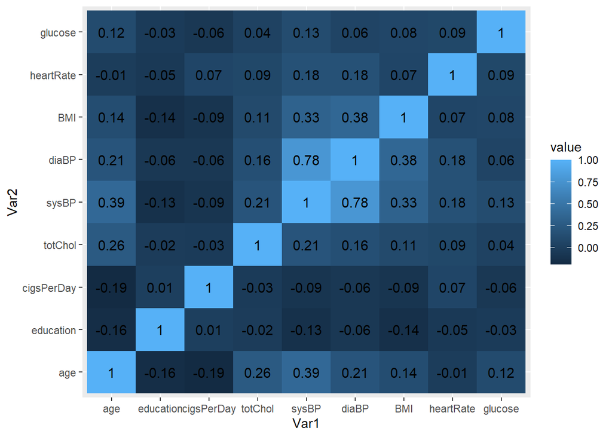

```r
# plotting the correlation heatmap
library(ggplot2)
ggplot(data = melted_corr_mat, aes(x=Var1, y=Var2,
                                   fill=value)) +
geom_tile() +
geom_text(aes(Var2, Var1, label = value),
          color = "black",size=4)
```

# 5 Plots

## 5.1 Univariate analysis.

### 5.1.1 Density plot of Age

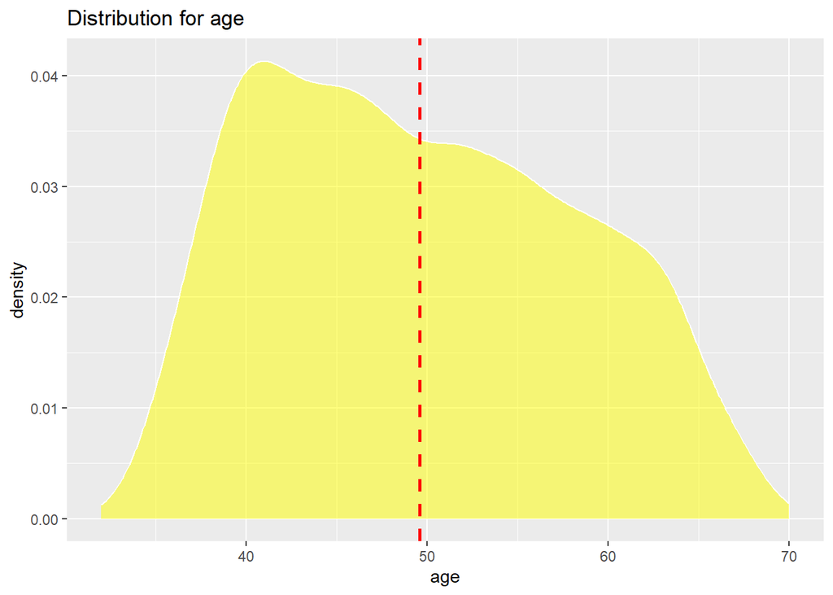

```r
ggplot(stroke_df, aes(x=age)) +
    geom_density(colour="white", fill="yellow",alpha=0.5) +
    geom_vline(aes(xintercept=mean(age, na.rm=T)),   # Ignore NA values for mean
               color="red", linetype="dashed",size=1) +
  ggtitle("Distribution for age")
```

### 5.1.2 Density plot for BMI

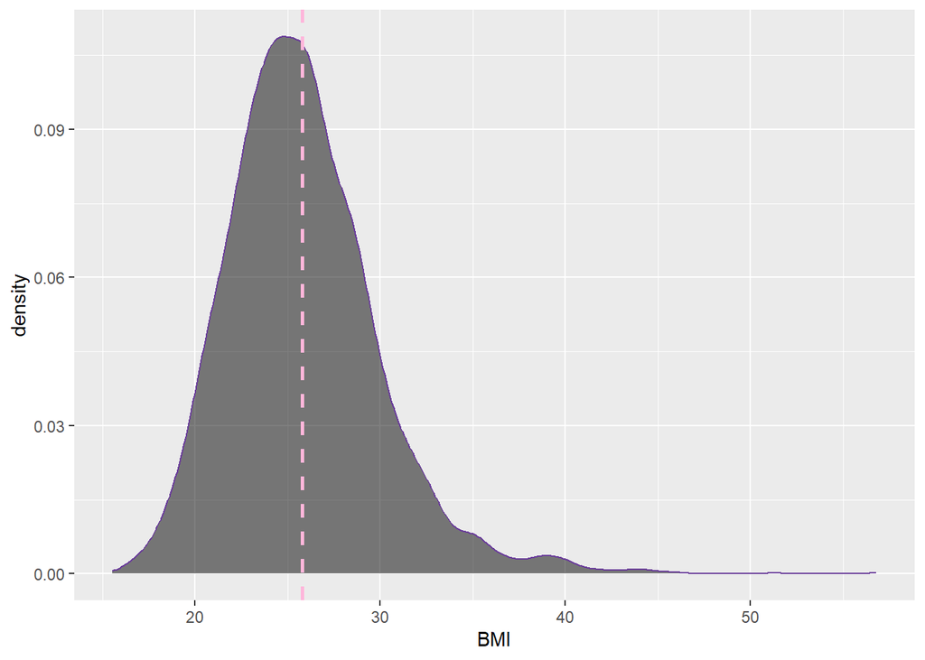

```r
ggplot(stroke_df, aes(x = BMI)) +
  geom_density(
    fill = "black",
    color = "#6A3D9A",
    alpha = 0.5
  ) +geom_vline(aes(xintercept=mean(BMI, na.rm=T)),   # Ignore NA values for mean
               color="#FEB6DB", linetype="dashed",size=1)
```

```r
  theme_bw() +
  theme() +
  ggtitle("Distribution for BMI")
```

[output not shown]

[output cut: 369 more lines]

[output not shown]

This density plot depicts a smooth line which represents the density of BMI values in our dataset. The higher the peak of the line, the more values there are in that range. Conversely, the lower the peak, the fewer values there are in that range. From this plot, within the BMI range of 20 to 30, with a peak value of 25 BMI, more observations are recorded.

### 5.1.3 Density plot for glucose

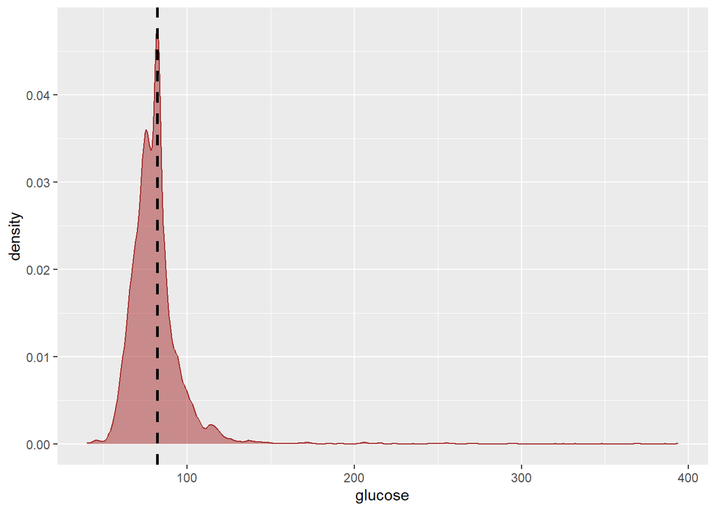

```r
ggplot(stroke_df, aes(x = glucose)) +
  geom_density(
    fill = "brown",
    color = "brown",
    alpha = 0.5
  ) +geom_vline(aes(xintercept=mean(glucose, na.rm=T)),   # Ignore NA values for mean
               color="black", linetype="dashed",size=1)
```

```r
  ggtitle("Distribution for Glucose Level") +
  theme_bw()+theme()
```

### 5.1.4 Bar plot to count the number of Males and Females in the Dataset

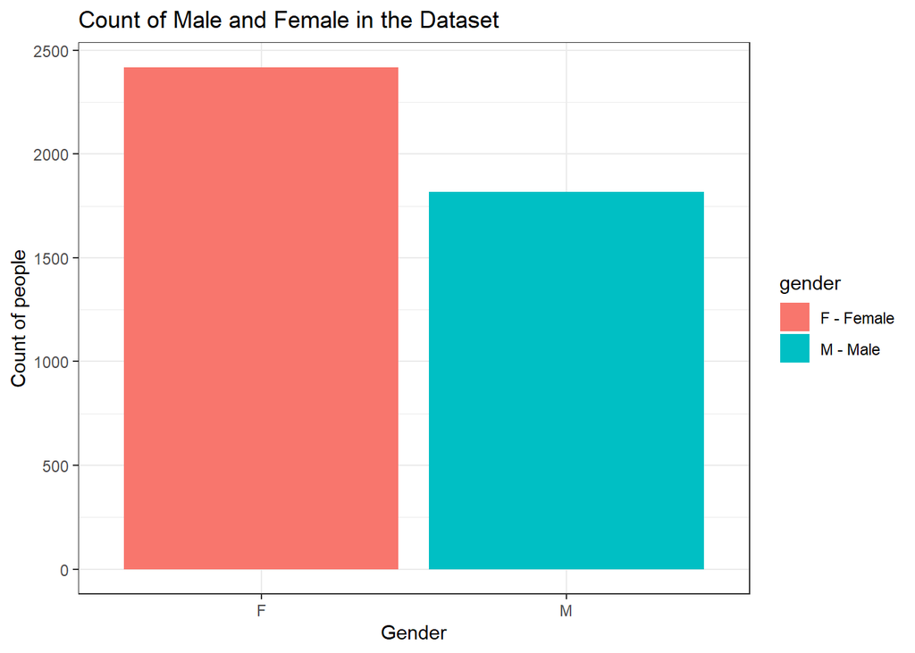

```r
ggplot(stroke_df, aes(x = gender, fill = gender)) +
  geom_bar() +
  ggtitle("Count of Male and Female in the Dataset") +
  theme_bw() +
  theme() +
  xlab("Gender") +
  ylab("Count of people") +
  scale_fill_discrete(name = "gender", labels = c("F - Female", "M - Male"))
```

This bar chart represents the gender distribution of all the patients in the dataset. It shows the count of male and female patients. We have around 2400 female records and 1800 male records in the dataframe.

## 5.2 Distribution of the target variable (stroke)

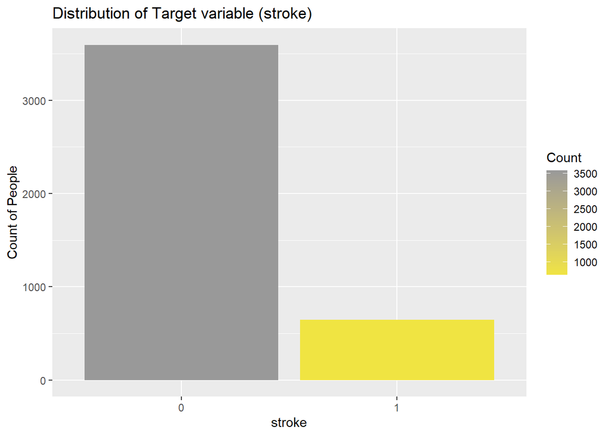

```r
ggplot(stroke_df, aes(x = stroke)) +
  geom_bar(aes(fill = ..count..)) +
  scale_fill_gradient("Count", low = "#F0E442", high = "#999999") +
  labs(x = "stroke", y = "Count of People", title = "Distribution of Target variable (stroke)")
```

This bar plot illustrates the distribution of the target variable (stroke - which means the ten year risk of coronary heart disease). Labels represents 0 - as records of people with no-stroke and 1 - as records of people with stroke. From the graph, it is shown as the dataset we have is imbalanced data which address our 2nd smart question - which leads further investigations and modifying the data using sampling techniques such as under-sampling and over-sampling.

## 5.3 Multi-Variate analysis.

### 5.3.1 BMI vs stroke

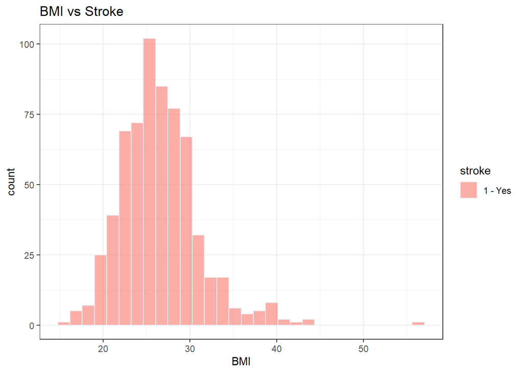

```r
ggplot(stroke_1, aes(x = BMI,
                     fill = stroke)) +
  geom_histogram(
    color = "#e9ecef",
    alpha = 0.6,
    position = "identity",
  ) +
  theme_bw() +
  theme() +
  ggtitle("BMI vs Stroke") +
  scale_fill_discrete(name = "stroke", labels = c("1 - Yes"))
```

### 5.3.2 Does it depend based on the gender?

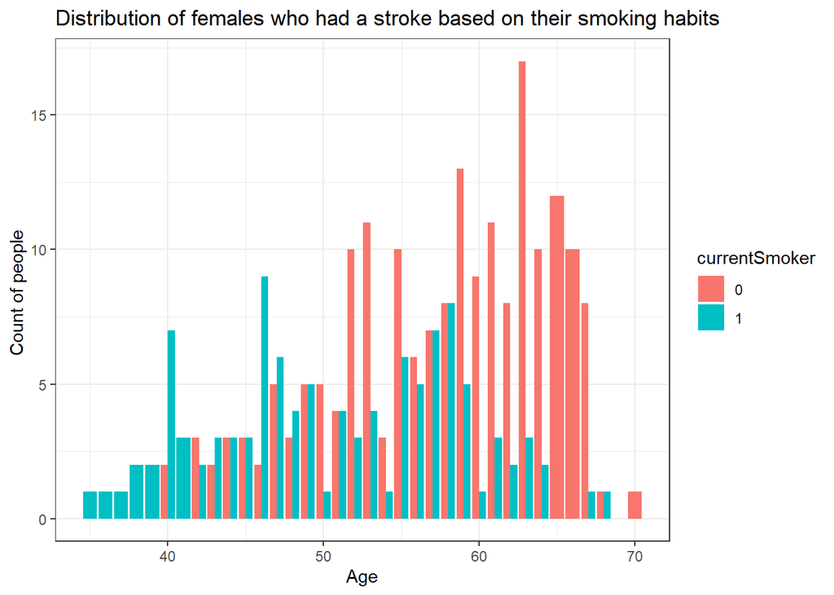

```r
# seeing if gender has any affect on stroke based on smoking and Age
ggplot(stroke_1_female, aes(x = age, fill = currentSmoker)) +
  geom_bar(position = "dodge") +
  ggtitle("Distribution of females who had a stroke based on their smoking habits") +
  theme_bw() +
  theme() +
  xlab("Age") +
  ylab("Count of people ")
```

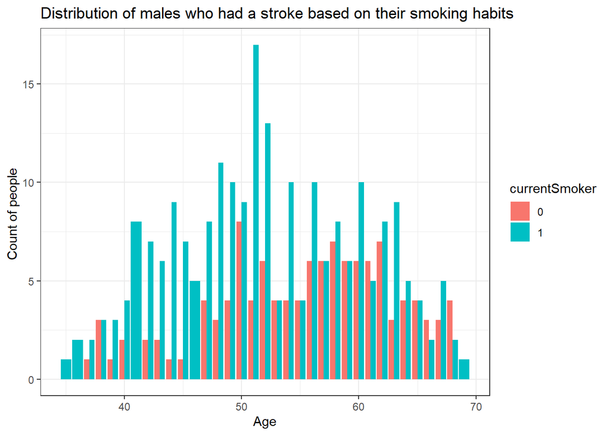

```r
ggplot(stroke_1_male, aes(x = age, fill = currentSmoker)) +
  geom_bar(position = "dodge") +
  ggtitle("Distribution of males who had a stroke based on their smoking habits") +
  theme_bw() +
  theme() +
  xlab("Age") +
  ylab("Count of people ")
```

As seen in the graph above, the key causes that caused a stroke in females were never smoked and it may be dependent on other variables.

Whereas in males, the reason for stroke was due to the current smoking habit.

### 5.3.3 Does age has significant effect on the stroke?

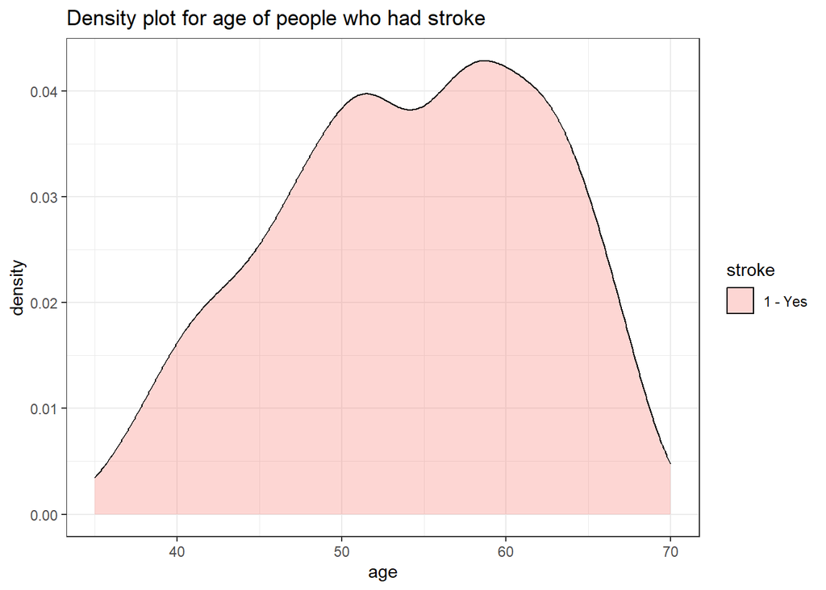

```r
# seeing if age has effect in stroke

ggplot(stroke_1, aes(x = age, fill = stroke)) +
  geom_density(alpha = 0.3) +
  ggtitle("Density plot for age of people who had stroke") +
  theme_bw() +
  theme() +
  scale_fill_discrete(name = "stroke", labels = c("1 - Yes"))
```

In general, we know that as one gets older, the likelihood of contracting an illness increases.

### 5.3.4 Does BMI with age cause stroke?

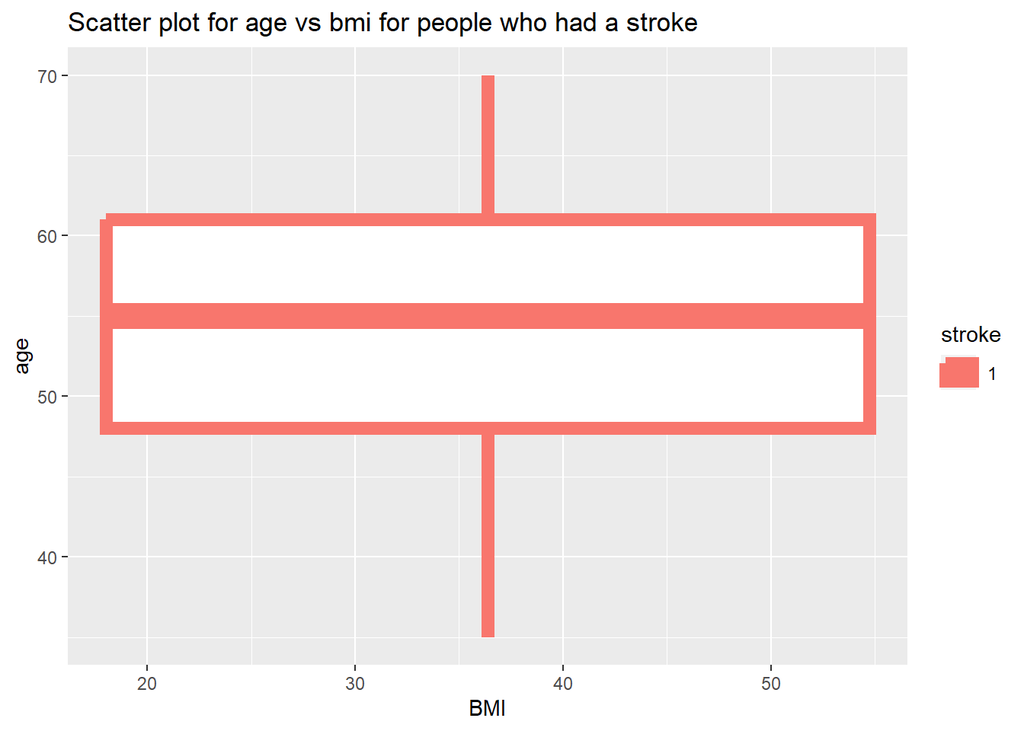

```r
# how bmi and age is stroke in people
ggplot(stroke_1, aes(x = BMI, y = age, color = stroke)) +
  geom_boxplot(size = 3) +
  ggtitle("Scatter plot for age vs bmi for people who had a stroke") +
  scale_fill_discrete(name = "stroke", labels = c("1 - Yes"))
```

The categories are encoded as:

- Underweight - BMI < 18.5
- Normal - BMI >= 18.5 and BMI <= 25
- Overweight - BMI >= 25.0 and BMI <= 30
- Obesity - BMI >= 30.0 and BMI < 40
- “Extreme” or Severe Obesity - BMI >= 40

### 5.3.5 BMI-categories vs Age.

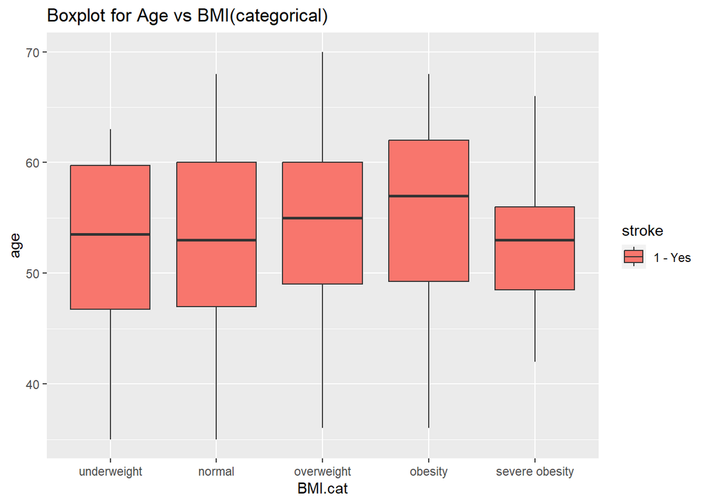

```r
dat_1 <- subset(dat, stroke == 1)

# boxplot to see if bmi along with age has anything to do with stroke
ggplot(dat_1, aes(x = BMI.cat, y = age, fill = stroke)) +
  geom_boxplot() +
  ggtitle("Boxplot for Age vs BMI(categorical)") +
  scale_fill_discrete(name = "stroke", labels = c("1 - Yes"))
```

This box plot that we plotted for BMI and the age and filled by who effected with heart stroke.

We converted BMI as a categorical variable into several groups like (underweight, normal, overweight,obesity,severe obesity) as per our observation the people who are in the overweight category and age range of 50 -65 years are the most people who had influenced heart attack.

### 5.3.6 Does age with glucose level affect stroke?

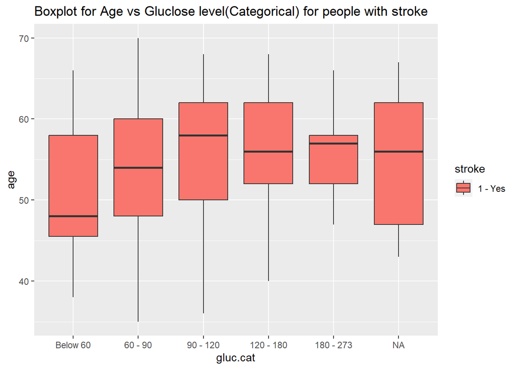

```r
# seeing if average glucose level with age has an effect on stroke

ggplot(dat_1, aes(fill = stroke, y = age, x = gluc.cat)) +
  geom_boxplot() +
  ggtitle("Boxplot for Age vs Gluclose level(Categorical) for people with stroke") +
  scale_fill_discrete(name = "stroke", labels = c("1 - Yes"))
```

The box plot is for the combination of age versus gluclose, where the gluclose variable is translated as a categorical variable into several categories like as (Below 60, 60-90, 90-120, 180-273).

Those with gluclose levels above 90 and ages 50 to 60 are more likely to have a heart attack.

### 5.3.7 Does age cause hypertension?

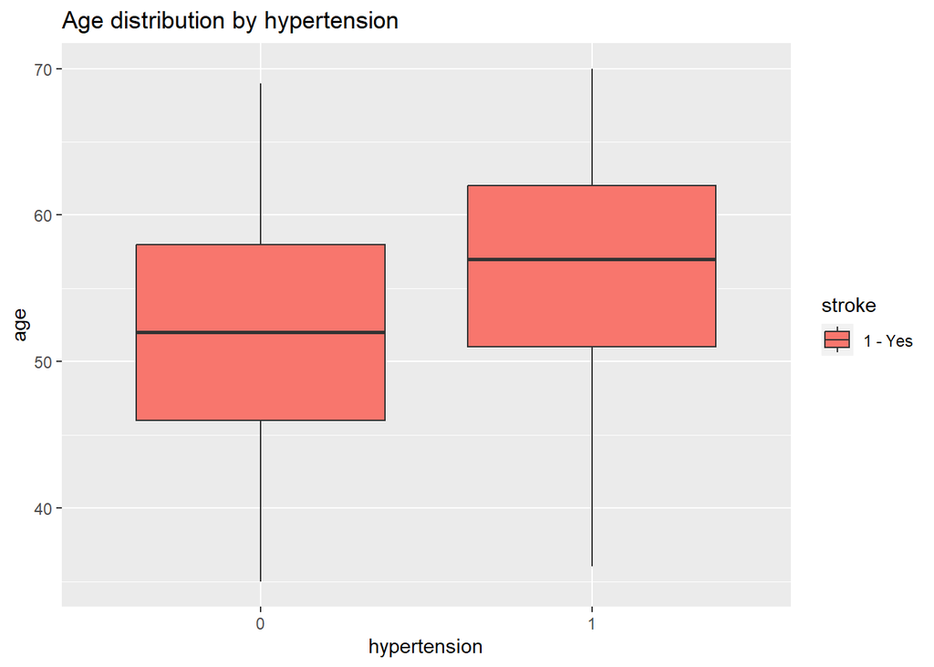

```r
# seeing if a person can get hypertension with age

ggplot(data = stroke_1, aes(
  x = as.character(prevalentHyp),
  y = age,
  fill = stroke
)) +
  geom_boxplot() +
  labs(title = "Age distribution by hypertension", x = "hypertension", y = "age") +
  scale_fill_discrete(name = "stroke", labels = c("1 - Yes"))
```

This Box plot that we created for the combination of hypertension and age (the person who was affected by heart stroke), where hypertension - 0 represents people who did not have hypertension and hypertension-1 represents people who did have hypertension.

According to the graph,those who in the age netween 50 to 60 years and those with hypertension are more likely to have a heart attack.

### 5.3.8 Does BMI alone cause stroke?

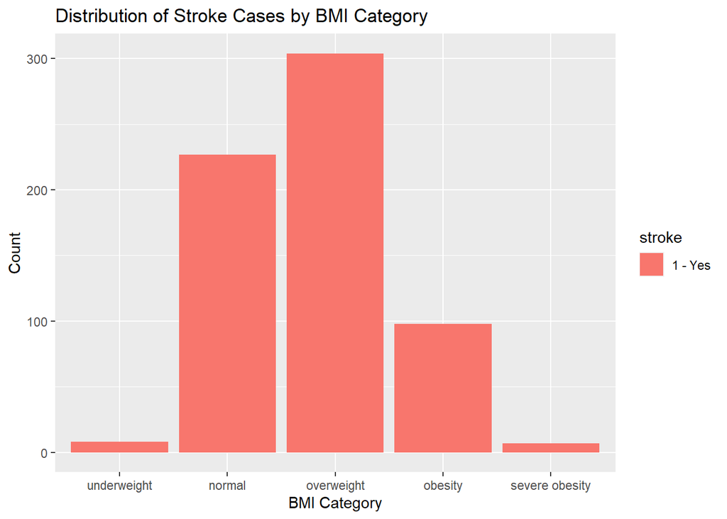

```r
# BMI category vs stroke count

ggplot(dat_1, aes(x = BMI.cat, fill = stroke)) +
  geom_bar() +
  labs(x = "BMI Category", y = "Count", title = "Distribution of Stroke Cases by BMI Category") +
  scale_fill_discrete(name = "stroke", labels = c("1 - Yes"))
```

This bar plot that we plotted for BMI and the person who effected with heart stroke.

We converted BMI as a categorical variable into several groups like (underweight, normal, overweight,obesity,severe obesity) as per our observation the people who are in the overweight category are the most people who had influenced heart attack.

### 5.3.9 Distribution of Age by Stroke Status.

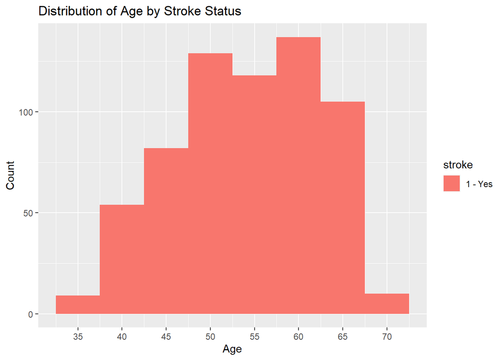

```r
ggplot(stroke_1, aes(x = age, fill = stroke)) +
  geom_histogram(binwidth = 5, position = "dodge") +
  labs(x = "Age", y = "Count", title = "Distribution of Age by Stroke Status") +
  scale_x_continuous(breaks = seq(0, 100, by = 5)) +
  scale_fill_discrete(name = "stroke", labels = c("1 - Yes"))
```

### 5.3.10 Does BMI and Glucose together cause stroke?

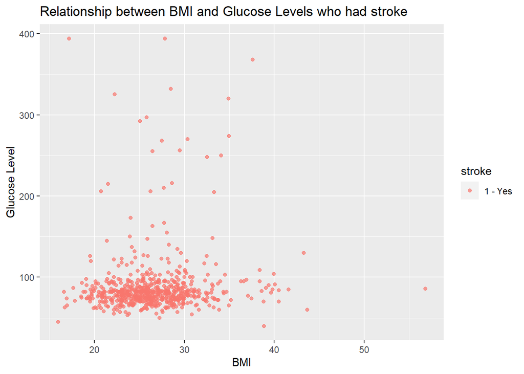

```r
ggplot(stroke_1, aes(x = BMI, y = glucose, color = stroke)) +
  geom_point(alpha = 0.7) +
  labs(x = "BMI", y = "Glucose Level", title = "Relationship between BMI and Glucose Levels who had stroke") +
  scale_color_manual(values = c("lightblue", "red")) +
  scale_color_discrete(name = "stroke", labels = c("1 - Yes"))
```

This scatter plot depicts the relationship between BMI and Glucose level in stroke patients.

In the plot, the x-axis (BMI) ranges from 0 to 60 and y-axis (glucose level) ranges from 50 to 400. People with a BMI of 20 to 30 range and a glucose level of less than 100 are recorded as the most number of people who are affected with the stroke.

### 5.3.11 How sysBP and diaBP along with age groups together cause stroke?

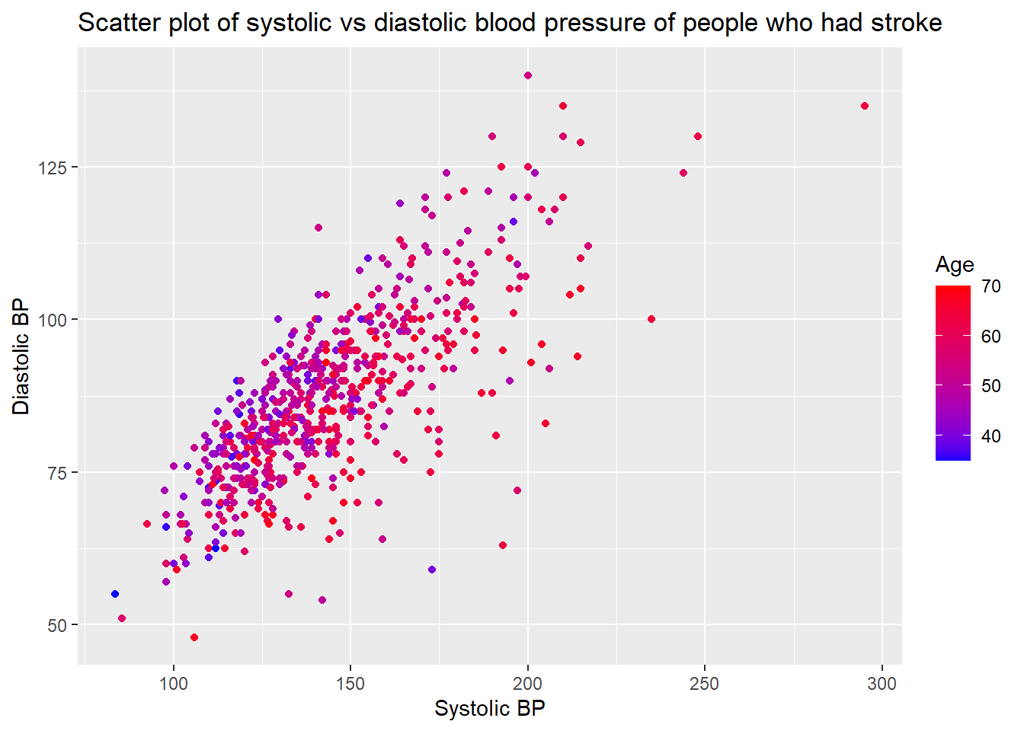

```r
ggplot(dat_1, aes(x = sysBP, y = diaBP, color = age)) +
  geom_point() +
  labs(
    title = "Scatter plot of systolic vs diastolic blood pressure of people who had stroke",
    x = "Systolic BP",
    y = "Diastolic BP",
    color = "Age"
  ) +
  scale_color_gradient(low = "blue", high = "red")
```

This scatter plot depicts the relationship between Systolic Blood pressure and Diastolic Blood pressure in stroke patients.

In the plot, the x-axis (Systolic BP) ranges from 50 to 300 and y-axis (Diastolic BP) ranges from 50 to 150.

# 6 Hypothesis testing

Null Hypothesis (H0) = There is no relationship between the predictor variables (Age, Hypertension, SysBP, DiaBP …) and the outcome of stroke occurrence.

Alternate Hypothesis (H1/Ha) = there is a relationship between at least one of the predictor variables as a risk factor and the outcome.

## 6.1 Statistical Chi-Square test for predictor variables (categorical) with target variable (Stroke)

For categorical variables, we are calculating p-vlaue using chi-square test.

### 6.1.1 chi square test for gender

```r
gender_chi_res <- chisq.test(stroke_df$stroke, stroke_df$gender)
gender_chi_res
```

```
##
##  Pearson's Chi-squared test with Yates' continuity correction
##
## data:  stroke_df$stroke and stroke_df$gender
## X-squared = 32.643, df = 1, p-value = 1.107e-08
```

### 6.1.2 chi square test for currentSmoker

```r
currentSmoker_chi_res <- chisq.test(stroke_df$stroke, stroke_df$currentSmoker)
currentSmoker_chi_res
```

```
##
##  Pearson's Chi-squared test with Yates' continuity correction
##
## data:  stroke_df$stroke and stroke_df$currentSmoker
## X-squared = 1.4977, df = 1, p-value = 0.221
```

### 6.1.3 chi square test for prevalentStroke

```r
prevalentStroke_chi_res <- chisq.test(stroke_df$stroke, stroke_df$prevalentStroke)
prevalentStroke_chi_res
```

```
##
##  Pearson's Chi-squared test with Yates' continuity correction
##
## data:  stroke_df$stroke and stroke_df$prevalentStroke
## X-squared = 14.021, df = 1, p-value = 0.0001808
```

### 6.1.4 chi square test for prevalentHyp

```r
prevalentHyp_chi_res <- chisq.test(stroke_df$stroke, stroke_df$prevalentHyp)
prevalentHyp_chi_res
```

```
##
##  Pearson's Chi-squared test with Yates' continuity correction
##
## data:  stroke_df$stroke and stroke_df$prevalentHyp
## X-squared = 132.61, df = 1, p-value < 2.2e-16
```

### 6.1.5 chi square test for diabetes

```r
diabetes_chi_res <- chisq.test(stroke_df$stroke, stroke_df$diabetes)
diabetes_chi_res
```

```
##
##  Pearson's Chi-squared test with Yates' continuity correction
##
## data:  stroke_df$stroke and stroke_df$diabetes
## X-squared = 38.442, df = 1, p-value = 5.641e-10
```

## 6.2 Statistical t-test for predictor variables (numerical) with target variable (Stroke)

For numerical variables, we are calculating p-vlaue using t-test.

### 6.2.1 t-test for totChol

```r
totChol_t_test <- t.test(totChol ~ stroke, data = stroke_df)
totChol_t_test
```

```
##
##  Welch Two Sample t-test
##
## data:  totChol by stroke
## t = -4.997, df = 845.27, p-value = 7.077e-07
## alternative hypothesis: true difference in means between group 0 and group 1 is not equal to 0
## 95 percent confidence interval:
##  -14.036020  -6.119273
## sample estimates:
## mean in group 0 mean in group 1
##        235.1902        245.2678
```

### 6.2.2 t-test for sysBP

```r
sysBP_t_test <- t.test(sysBP ~ stroke, data = stroke_df)
sysBP_t_test
```

```
##
##  Welch Two Sample t-test
##
## data:  sysBP by stroke
## t = -12.015, df = 783.92, p-value < 2.2e-16
## alternative hypothesis: true difference in means between group 0 and group 1 is not equal to 0
## 95 percent confidence interval:
##  -15.45567 -11.11468
## sample estimates:
## mean in group 0 mean in group 1
##        130.3336        143.6188
```

### 6.2.3 t-test for diaBP

```r
diaBP_t_test <- t.test(diaBP ~ stroke, data = stroke_df)
diaBP_t_test
```

```
##
##  Welch Two Sample t-test
##
## data:  diaBP by stroke
## t = -8.2513, df = 800.41, p-value = 6.424e-16
## alternative hypothesis: true difference in means between group 0 and group 1 is not equal to 0
## 95 percent confidence interval:
##  -5.967145 -3.673662
## sample estimates:
## mean in group 0 mean in group 1
##        82.16096        86.98137
```

### 6.2.4 t-test for BMI

```r
BMI_t_test <- t.test(BMI ~ stroke, data = stroke_df)
BMI_t_test
```

```
##
##  Welch Two Sample t-test
##
## data:  BMI by stroke
## t = -4.4831, df = 833.92, p-value = 8.385e-06
## alternative hypothesis: true difference in means between group 0 and group 1 is not equal to 0
## 95 percent confidence interval:
##  -1.2175404 -0.4760483
## sample estimates:
## mean in group 0 mean in group 1
##        25.67333        26.52012
```

### 6.2.5 t-test for age

```r
age_t_test <- t.test(age ~ stroke, data = stroke_df)
age_t_test
```

```
##
##  Welch Two Sample t-test
##
## data:  age by stroke
## t = -15.577, df = 916.27, p-value < 2.2e-16
## alternative hypothesis: true difference in means between group 0 and group 1 is not equal to 0
## 95 percent confidence interval:
##  -6.055917 -4.700671
## sample estimates:
## mean in group 0 mean in group 1
##        48.76767        54.14596
```

### 6.2.6 t-test for glucose

```r
glucose_t_test <- t.test(glucose ~ stroke, data = stroke_df)
glucose_t_test
```

```
##
##  Welch Two Sample t-test
##
## data:  glucose by stroke
## t = -4.8245, df = 691.75, p-value = 1.728e-06
## alternative hypothesis: true difference in means between group 0 and group 1 is not equal to 0
## 95 percent confidence interval:
##  -10.775617  -4.541914
## sample estimates:
## mean in group 0 mean in group 1
##        80.80294        88.46170
```

# 7 Conclusions from EDA:

As per this data the chances of hypertension, diastolic BP and systolic BP in a person is higher when he/she is older which can lead to a stroke.

# 8 Findings:

As from the distribution plot of the target variable, which clearly depicts that the dataset is considered to be im-balanced and this required suitable sampling methods in order to prepare the data for the model building.

# 9 Addressing data im-balance issue:

These lines of code are used to split the dataset into training and testing sets using the createDataPartition function from the caret package in R. createDataPartition function is used to create a stratified random sample of the stroke variable, with a 70/30 split for the training and testing datasets respectively.

```r
set.seed(123)

train_index <- createDataPartition(stroke_df$stroke, p = 0.7,
                                   list = FALSE, times = 1)

train_data <- stroke_df[train_index, ]
test_data <- stroke_df[-train_index, ]
```

Since the classes are not balanced (0=3594, 1=644), I will use SMOTE to balance the train data since if we treat them as they are, our model will predict on the class that is in the majority, which will be biased.

```r
# Count the number of observations in each class before SMOTE
print("Distribution of target variable in train data before SMOTE technique: ")
```

```
## [1] "Distribution of target variable in train data before SMOTE technique: "
```

```r
print(table(train_data$stroke))
```

```
##
##    0    1
## 2516  451
```

```r
# Apply SMOTE to balance the classes
train_data_balanced <- DMwR::SMOTE(stroke ~ .,
                             train_data,
                             perc.over = 300,
                             perc.under = 140)

# Count the number of observations in each class after SMOTE
print("Distribution of target variable in train data after SMOTE technique: ")
```

```
## [1] "Distribution of target variable in train data after SMOTE technique: "
```

```r
print(table(train_data_balanced$stroke))
```

```
##
##    0    1
## 1894 1804
```

```r
print(paste("Total number of observations in balanced train data: ", nrow(train_data_balanced)))
```

```
## [1] "Total number of observations in balanced train data:  3698"
```

Before applying SMOTE, there were 2516 observations with stroke=0 and 451 observations with stroke=1 in the training data. After applying SMOTE to balance the classes, there were 1894 observations with stroke=0 and 1804 observations with stroke=1 in the balanced training data.

The total number of observations in the balanced training data is 3698, which is higher than the original training data because SMOTE creates synthetic data points to balance the classes.

## 9.1 Distribution of the target variable (stroke) after balancing

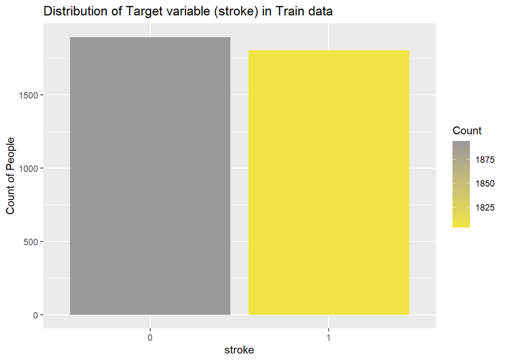

```r
ggplot(train_data_balanced, aes(x = stroke)) +
  geom_bar(aes(fill = ..count..)) +
  scale_fill_gradient("Count", low = "#F0E442", high = "#999999") +
  labs(x = "stroke", y = "Count of People", title = "Distribution of Target variable (stroke) in Train data")
```

## 9.2 Model Building with Balanced data with all features

### 9.2.1 Model Building - 1: Decision Tree

```r
library(rpart)

# Fit decision tree model
tree_model_bal <- rpart(stroke ~ .,
                    data = train_data_balanced,
                    method="class")


# Make predictions on the test data
test_preds <- predict(tree_model_bal,
                      test_data,
                      type="class")


# print confusion matrix
dt_confusion_mat <- confusionMatrix(factor(test_preds, levels = c(0, 1)),
                                 factor(test_data$stroke, levels = c(0, 1)),
                                 mode = 'everything')

print("Confusion matrix from decision tree: ")
```

```
## [1] "Confusion matrix from decision tree: "
```

```r
print(dt_confusion_mat$table)
```

```
##           Reference
## Prediction   0   1
##          0 932 144
##          1 146  49
```

```r
# calculate model performance metrics
accuracy <- dt_confusion_mat$overall['Accuracy']
precision <- dt_confusion_mat$byClass['Pos Pred Value']
sensitivity <- dt_confusion_mat$byClass['Sensitivity']
specificity <- dt_confusion_mat$byClass['Specificity']
f1_score <- 2 * (precision * sensitivity) / (precision + sensitivity)

# print performance metrics
print(paste("Accuracy: ", round(accuracy, 4) * 100, "%"))
```

```
## [1] "Accuracy:  77.18 %"
```

```r
print(paste("Precision: ", round(precision, 4) * 100, "%"))
```

```
## [1] "Precision:  86.62 %"
```

```r
print(paste("Recall (Sensitivity): ", round(sensitivity, 4) * 100, "%"))
```

```
## [1] "Recall (Sensitivity):  86.46 %"
```

```r
print(paste("Specificity: ", round(specificity, 4) * 100, "%"))
```

```
## [1] "Specificity:  25.39 %"
```

```r
print(paste("F1 Score: ", round(f1_score, 4) * 100, "%"))
```

```
## [1] "F1 Score:  86.54 %"
```

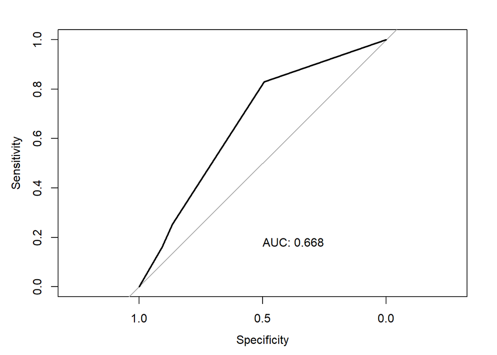

```r
# AUC-ROC curve
library(pROC)

prob_dt <- predict(tree_model_bal,
                test_data,
                type = "prob")

ROC_dt <- roc(test_data$stroke,
              prob_dt[,2])
auc_val_dt <- auc(ROC_dt)

plot(ROC_dt,
     print.auc = TRUE,
     print.auc.x = 0.5,
     print.auc.y = 0.2)
```

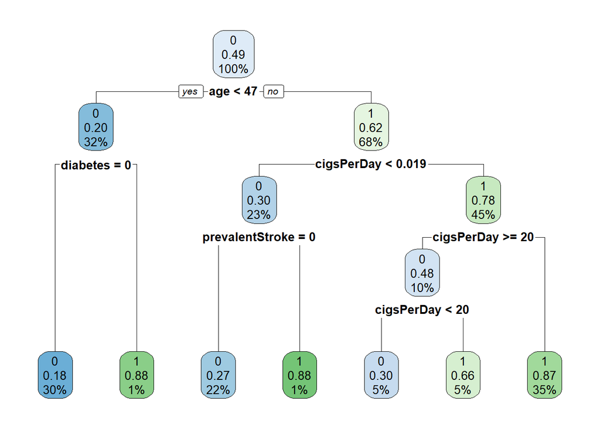

```r
# decision tree fit
fit <- rpart(stroke ~ .
             , data = train_data_balanced,
             method = 'class')

rpart.plot(fit, extra = 106)
```

The model is based on a dataset with 3698 instances, where each instance has a set of attributes and a binary class label (0 or 1).

The root node is the starting point of the tree, and it includes all 3698 instances. The root node split the data based on the “age” attribute. If the age is less than 47.02149, the data goes to node 2; otherwise, it goes to node 3.

Node 2 includes 1165 instances with the age less than 47.02149, and it further splits the data based on the “diabetes” attribute. If the diabetes is 0, the instance belongs to node 4, which includes 1124 instances with 0 class labels, and it is marked as a terminal node with a “*.” If the diabetes is 1, the instance belongs to node 5, which includes 41 instances with 1 class label, and it is also marked as a terminal node.

```r
# Count the number of observations in each class before SMOTE
table(test_data$stroke)
```

```
##
##    0    1
## 1078  193
```

```r
test_data_balanced <- test_data

# # Apply SMOTE to balance the classes
# test_data_balanced <- SMOTE(stroke ~ .,
#                              test_data,
#                              perc.over = 300,
#                              perc.under = 130)
#
# # Count the number of observations in each class after SMOTE
# table(test_data_balanced$stroke)
#
print(paste("Number of observations in test data split: ", nrow(test_data_balanced)))
```

```
## [1] "Number of observations in test data split:  1271"
```

### 9.2.2 Tuned Decision Tree with all variables

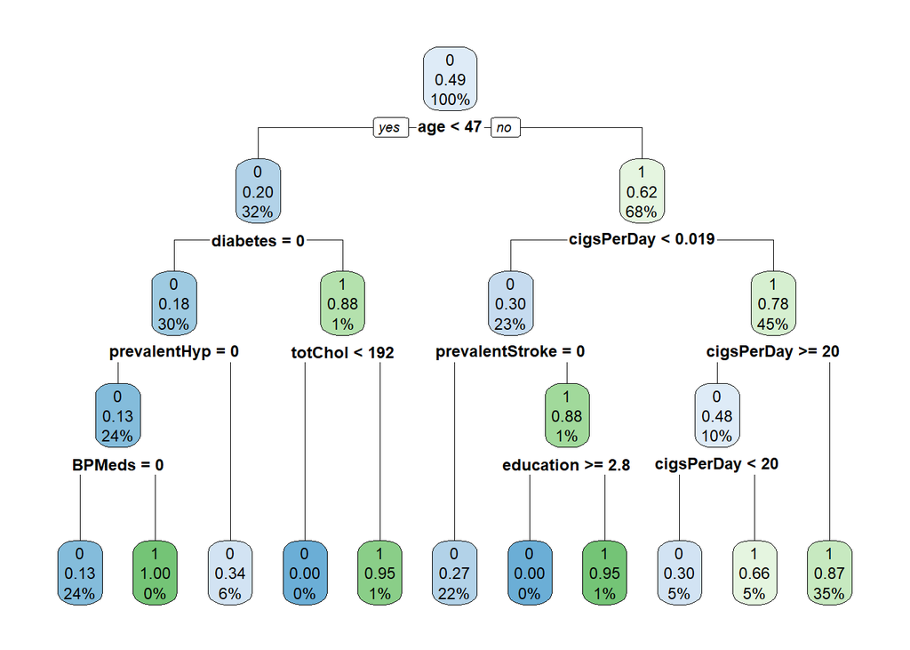

```r
control <- rpart.control(minsplit = 7,
                          minbucket = round(5 / 3),
                          maxdepth = 4,
                          cp = 0)

tune_fit <- rpart(stroke ~ .,
                  data = train_data_balanced,
                  method = 'class', control = control)
rpart.plot(tune_fit, extra = 106)
```

```r
# Prediction
predict_unseen1 <-predict(tune_fit,
                          test_data,
                          type = 'class')

# Eval Metric
confusion1= confusionMatrix(predict_unseen1,
                            test_data$stroke,
                            mode= "everything")

confusion1
```

```
## Confusion Matrix and Statistics
##
##           Reference
## Prediction   0   1
##          0 933 145
##          1 145  48
##
##                Accuracy : 0.7718
##                  95% CI : (0.7478, 0.7946)
##     No Information Rate : 0.8482
##     P-Value [Acc > NIR] : 1
##
##                   Kappa : 0.1142
##
##  Mcnemar's Test P-Value : 1
##
##             Sensitivity : 0.8655
##             Specificity : 0.2487
##          Pos Pred Value : 0.8655
##          Neg Pred Value : 0.2487
##               Precision : 0.8655
##                  Recall : 0.8655
##                      F1 : 0.8655
##              Prevalence : 0.8482
##          Detection Rate : 0.7341
##    Detection Prevalence : 0.8482
##       Balanced Accuracy : 0.5571
##
##        'Positive' Class : 0
##
```

```r
# AUC-ROC curve

prob = predict(tune_fit,
               test_data,
               type="prob")

ROC_dt_tune <- roc(test_data$stroke, prob[,2])
auc_val_dt_tune <- auc(ROC_dt_tune)
auc_val_dt_tune
```

```
## Area under the curve: 0.6485
```

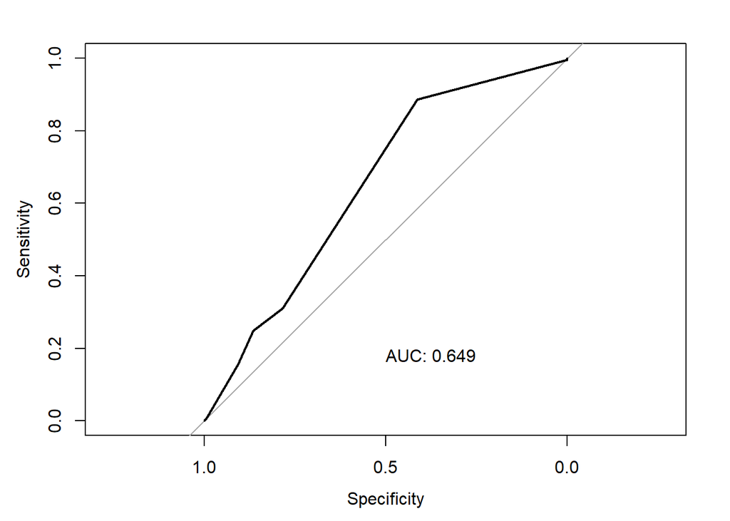

```r
plot(ROC_dt_tune,
     print.auc = TRUE,
     print.auc.x = 0.5,
     print.auc.y = 0.2)
```

### 9.2.3 Model building - 2: Random Forest

```r
rf_model_bal <- randomForest(stroke ~ .,
                         data = train_data_balanced,
                         importance = TRUE)

# make predictions on test data
test_preds_rf <- predict(rf_model_bal,
                         newdata = test_data)

# calculate accuracy
rf_model_accuracy <- sum(test_preds_rf == test_data$stroke) / nrow(test_data)

# calculate feature importance
rf_importance <- importance(rf_model_bal)
print(rf_importance)
```

```
##                        0           1 MeanDecreaseAccuracy MeanDecreaseGini
## gender          28.63562  -1.8636795             25.55430         19.72333
## age             68.18166  48.4606046             72.72095        261.78976
## education       28.04233  21.3000990             29.35196         65.09698
## currentSmoker   40.53624 -37.4272957             37.13717         67.25297
## cigsPerDay      66.57769  54.1785759             75.96818        298.45410
## BPMeds          42.33930   6.8641872             42.59475         63.11131
## prevalentStroke 21.34459  18.0094017             25.34441         20.85641
## prevalentHyp    44.96019 -10.4633815             44.74122         88.56435
## diabetes        37.22655  -0.4437034             36.10138         37.15291
## totChol         51.08896  20.4463355             50.59688        121.72088
## sysBP           57.85659  26.2005565             62.05659        211.00703
## diaBP           45.17155  20.6150053             48.78877        145.98957
## BMI             51.69576  20.4597055             51.21653        126.65968
## heartRate       44.98627  22.7901080             43.26009        106.05195
## glucose         54.76308  26.3859483             56.00247        147.02071
```

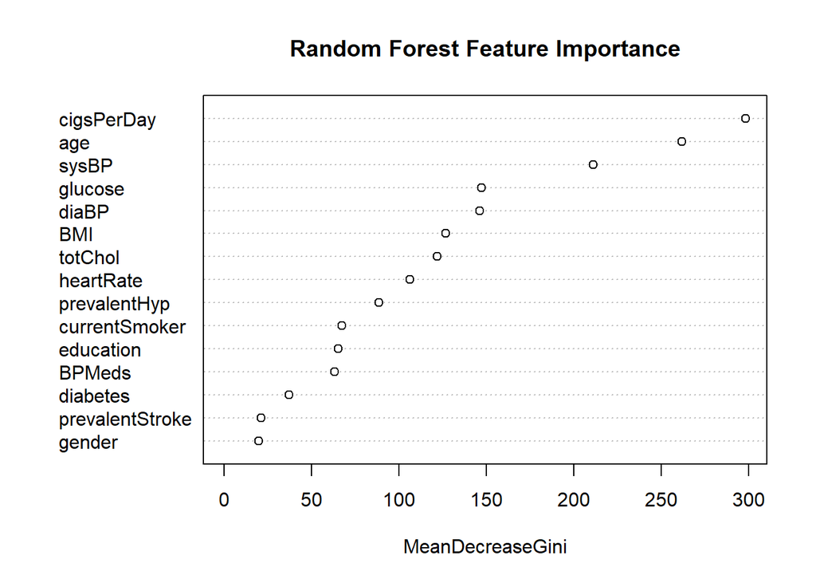

```r
# plot feature importance
varImpPlot(rf_model_bal, type = 2, main = "Random Forest Feature Importance")
```

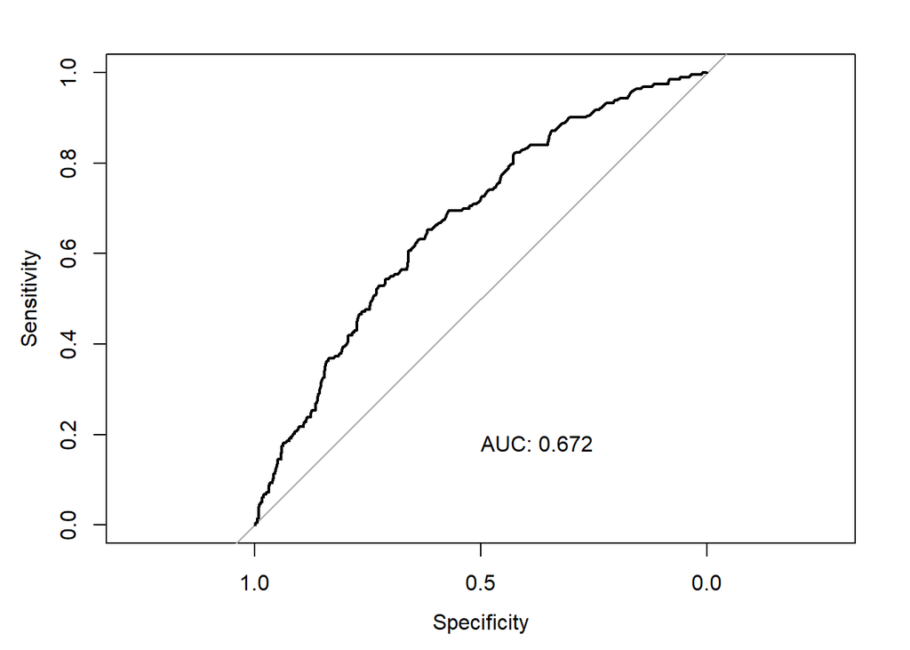

```r
rf_importance <- as.data.frame(rf_importance)

rf_importance <- rf_importance[order(rf_importance$MeanDecreaseGini,
                                     decreasing = TRUE),]


# AUC-ROC curve for RF model

prob_rf <- predict(rf_model_bal,
                test_data,
                type = "prob")

ROC_rf <- roc(test_data$stroke,
              prob_rf[,2])
auc_val_rf <- auc(ROC_rf)

plot(ROC_rf,
     print.auc = TRUE,
     print.auc.x = 0.5,
     print.auc.y = 0.2)
```

### 9.2.4 Random forest model evaluation metrics on balanced data

```r
# create confusion matrix
confusion_mat_rf <- confusionMatrix(data = test_preds_rf,
                                      reference = test_data$stroke)

# print accuracy
full_model_accuracy <- confusion_mat_rf$overall['Accuracy']
print(paste("Accuracy: ", round(full_model_accuracy, 4) * 100, "%"))
```

```
## [1] "Accuracy:  77.34 %"
```

```r
# print precision
full_model_precision <- confusion_mat_rf$byClass['Pos Pred Value']
print(paste("Precision: ", round(full_model_precision, 4) * 100, "%"))
```

```
## [1] "Precision:  86.71 %"
```

```r
# print recall (sensitivity)
full_model_sensitivity <- confusion_mat_rf$byClass['Sensitivity']
print(paste("Recall (Sensitivity): ", round(full_model_sensitivity, 4) * 100, "%"))
```

```
## [1] "Recall (Sensitivity):  86.55 %"
```

```r
# print specificity
full_model_specificity <- confusion_mat_rf$byClass['Specificity']
print(paste("Specificity: ", round(full_model_specificity, 4) * 100, "%"))
```

```
## [1] "Specificity:  25.91 %"
```

```r
# print F1 score
full_model_f1_score <- 2 * (confusion_mat_rf$byClass['Pos Pred Value'] * confusion_mat_rf$byClass['Sensitivity']) / (confusion_mat_rf$byClass['Pos Pred Value'] + confusion_mat_rf$byClass['Sensitivity'])

print(paste("F1 Score: ", round(full_model_f1_score, 4) * 100, "%"))
```

```
## [1] "F1 Score:  86.63 %"
```